# Division-Independent Methods

jharner

March 1, 2015

## All-Data Computation

While division and recombination methods focus on per-subset computation, there are times where we would like to compute statistics over the entire data set, regardless of division. `datadr` provides a set of methods for division-independent computations, meaning no matter how the data is divided, these methods will provide the same global summary of the data.

Currently it supports:

- tabulating data through a `drAggregate()` function;
- computing quantile estimates through a `drQuantile()` function (from which we can obtain other related quantities of interest, such as histograms, boxplots, etc.);
- performing hexagonal binning of two quantitiative variables through a `drHexbin()` function.

## Quantiles

The most common thing we tend to compute over the entire data other than summary statistics and tabulations is quantiles. With `datadr`, there is a very simple interface to computing quantiles over the entire data set regardless of division.

To be able to compute quantiles, a ddf must be supplied, and the `range` attribute of the variable of interest must have been computed using `updateAttributes()`. The range is required because the quantile estimation algorithm takes the range of the variable and slices it into a grid of `nBins` bins. Each observation of the variable is placed into the bin of the interval that it falls in and the bin counts are tabulated. Then the resulting table is turned into a quantile estimate.

The quantile estimation returns results similar to that of `type = 1` in R’s base `quantile()` function.

### Example: adult data

Here we provide a quick example of how to compute quantiles. We have implemented function `drQuantile()` that at a minimum requires a ddf and a specification of `var`, the variable you would like to compute the quantiles of.

We will use the `adult` data from before. Let’s load it and create a by education division:

```r
library(datadr)
# load adult data for quantile example
data(adult)
adultDdf <- ddf(adult)
# divide it by education
# must have update = TRUE to get range of variables
byEd <- divide(adultDdf, by = "education", update = TRUE)
```

```
## * Verifying parameters...
## * Applying division...
## * Running map/reduce to get missing attributes...
```

There’s no reason to divide by education other than to illustrate that this method operates on arbitrary divisions of the data.

We can compute the quantiles with:

```r
# compute quantiles of hoursperweek
hpwQuant <- drQuantile(byEd, var = "hoursperweek")
head(hpwQuant)
```

```
##           fval q
## 1 0.000000e+00 1
## 2 3.071159e-05 1
## 3 6.142317e-05 1
## 4 9.213476e-05 1
## 5 1.228463e-04 1
## 6 1.535579e-04 1
```

The result is simply a data frame of “f-values” `fval` and quantiles `q`. We can plot the result with:

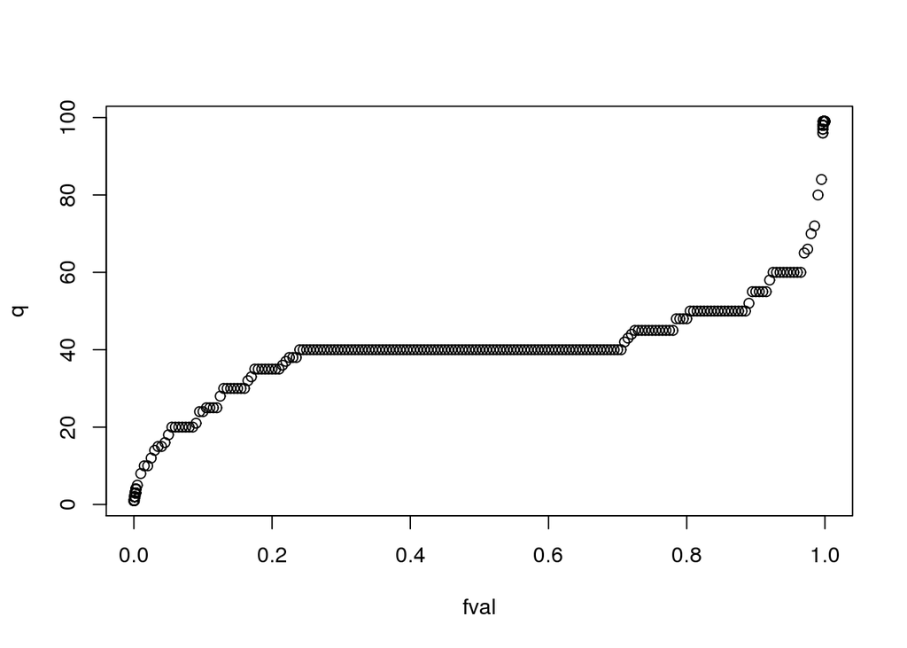

```r
plot(hpwQuant)
```

Recall the quantiles (y-axis) are hours worked in a week. Some people work too much.

### Keeping all data at the tails

A common thing we want to do with all-data quantile estimates is retain more observations in the tails. With large data sets and heavy tails, it can be good to know about all of the observations located in the tails. With `drQuantile()`, it is possible to specify a parameter `tails`, which you can set to a positive integer. The `tails` argument tells the quantile method how many exact observations to keep at each side of the distribution. These exact values are appended to the quantile estimates to provide more detail at the tails of the distribution. The default is `tails = 100`.

### Conditioning on variables

It is possible to condition on a categorical variable when computing quantiles, so that you get a distribution per level of that categorical variable. This can be useful when the data is very large for each category (otherwise, you can do this using `divide()` and `recombine())`. Here is an example of the quantiles of hours worked per week by gender:

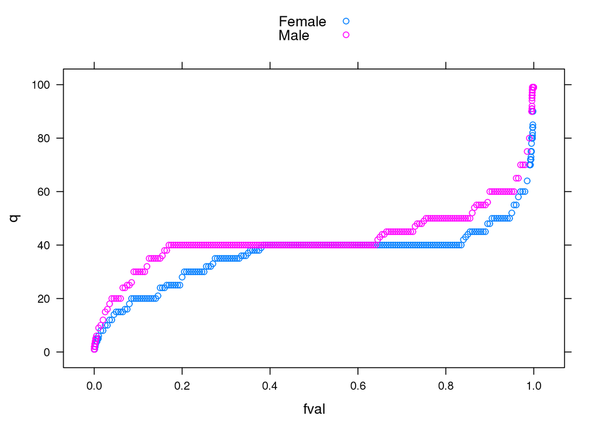

```r
library(lattice)
# compute quantiles of hoursperweek by sex
hpwBySexQuant <- drQuantile(byEd, var = "hoursperweek", by = "sex")
xyplot(q ~ fval, groups = sex, data = hpwBySexQuant, auto.key = TRUE)
```

## Aggregation

Division-independent aggregation can be done with `drAggregate()`. This function is similar to R’s`aggregate()` and `xtabs()`. It provides a formula interface to specifying both the quantity to sum and the variables to group by. Unlike `xtabs()`, `drAggregate()` returns a data frame with rows only for combinations of factors for which there was a positive frequency.

```r
# load adult data for aggregate example
data(adult)
adultDdf <- ddf(adult)
# divide it by education, for fun
byEd <- divide(adultDdf, by = "education", update = TRUE)
```

```
## * Verifying parameters...
## * Applying division...
## * Running map/reduce to get missing attributes...
```

```r
# get counts by race and gender
raceGender <- drAggregate(~ race + sex, data = byEd)
raceGender
```

```
##                  race    sex  Freq
## 10              White   Male 19174
## 5               White Female  8642
## 8               Black   Male  1569
## 3               Black Female  1555
## 7  Asian-Pac-Islander   Male   693
## 2  Asian-Pac-Islander Female   346
## 6  Amer-Indian-Eskimo   Male   192
## 9               Other   Male   162
## 1  Amer-Indian-Eskimo Female   119
## 4               Other Female   109
```

```r
# aggregate age by race and gender
totAge <- drAggregate(age ~ race + sex, data = byEd)
totAge
```

```
##                  race    sex   Freq
## 10              White   Male 760297
## 5               White Female 318126
## 8               Black   Male  59124
## 3               Black Female  58863
## 7  Asian-Pac-Islander   Male  27078
## 2  Asian-Pac-Islander Female  12141
## 6  Amer-Indian-Eskimo   Male   7144
## 9               Other   Male   5614
## 1  Amer-Indian-Eskimo Female   4417
## 4               Other Female   3453
```

## Hexagonal Binning

A useful binning approach for scatterplot summaries of large data is hexagonal binning. `datadr` provides a division-independent hexbin method that is pretty straightforward. A call to `drHexbin()` must specify at a minimum the input ddf, the name of the x and y variable. The remaining parameters are passed on to the individual `hexbin()` function in the `hexbin` package, which is applied to each subset and the results are aggregated.

Here is a simple example. Suppose we want a binned scatterplot of age vs. education using the `adult` data:

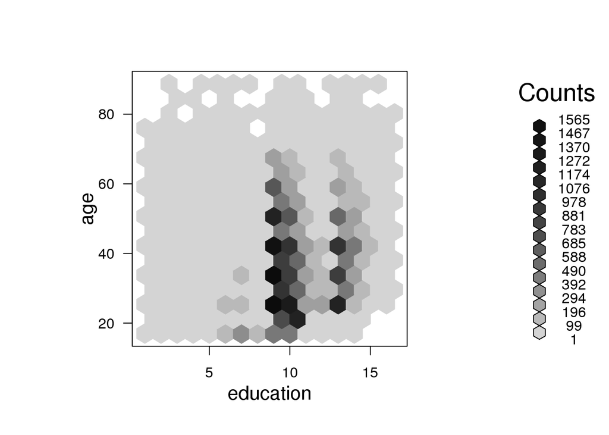

```r
library(hexbin)
# do hexbin aggregation on age and education
res <- drHexbin(byEd, "educationnum", "age", xbins = 15)
plot(res, xlab = "education", ylab = "age")
```